# Histograms and Resampling

PSTAT 134 (Winter 2026)

Author

Affiliation

Sang-Yun Oh

University of California, Santa Barbara

## Population vs. Sample

- Let $\mathcal{U} = \{U_1, U_2, \dots, U_N\}$ be all individuals in the population.
- $N$ can be finite (small or large) or infinite.
  - Small $N$: e.g., average age of last years Nobel laureates.
  - Large $N$: e.g., average height of all adults in the US.
  - Infinite $N$: e.g., dice rolls, physical experiments, simulations.
- If $N$ is small, we can measure all units (census)
- If $N$ is large or infinite, we take a sample of size $n$ from the population
- If we can measure all units, we can *compute statistical properties exactly*. If not, we can only *estimate them from the sample*.

## Data: Random Sample

- Let $\mathcal{U} = \{U_1, U_2, \dots, U_N\}$ be all individuals in the population.
- $N$ can be finite or infinite.
- Denote $n$ integers between $1$ and $N$ with equal probability as
  $$j_1,\ j_2,\ \dots,\ j_n$$
- Then, random sampling is defined as:
  $$u_1 = U_{j_1},\ u_2 = U_{j_2},\ \dots,\ u_n = U_{j_n}$$
- Assume random sampling is with replacement for simplicity.

## Data: Measurements from a Random Sample

- Let $x_i$ be the value of the variable of interest for unit $u_i$.
- Population - census measurements[^1] (from unique individuals):
  $$\mathcal{X} = (X_1, X_2, \dots, X_N)$$
- Observed data - measurements (can have repeats):
  $${\bf x} = (x_1, x_2, \dots, x_n).$$

## Data are Distributions

- Finite number of units: census or sample survey
- Infinite number of units: e.g., physical experiments, simulations
- All can be thought of as distributions
- Population distribution $F$ vs. empirical distribution $\hat{F}$
- Sample statistic estimates a population parameter. e.g., $\bar{x}$ estimates $\mu$.
- We can show if $\mu = E_{F}(X)$, then
  $$\mu_\hat{F} = E_{\hat{F}}(X) = \bar{x}$$

## Histogram as Probability Functions

```python
X = norm(loc=3, scale=1)

num_data = 100 # number of observations
num_bins = 20  # number of bins

x_data = X.rvs(num_data) # simulate data
bin_edges = np.linspace(-2, 8, num=num_bins+1)
bin_width = 10/num_bins

# histogram with density and counts
fhat, _ = np.histogram(x_data, bins=bin_edges, density=True)
counts, _ = np.histogram(x_data, bins=bin_edges, density=False)
```

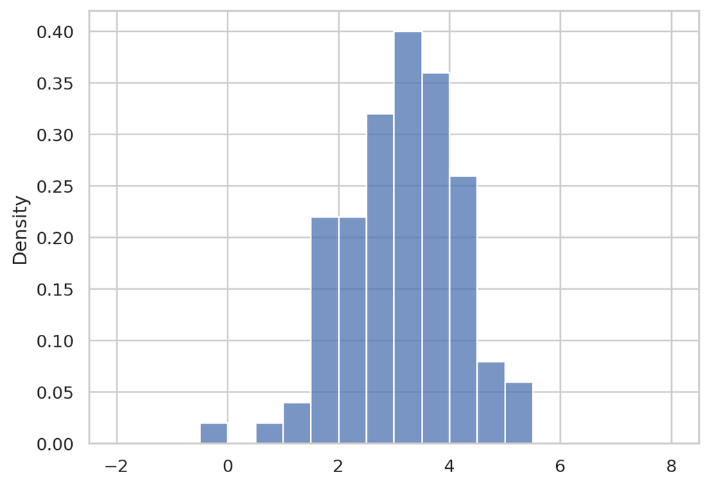

Histogram Density

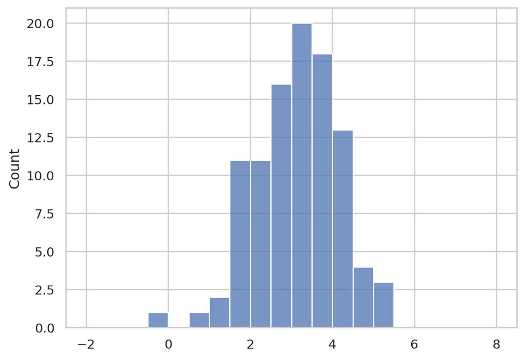

Histogram Counts

## Properties of Histograms

- `counts` is a scaled discrete distribution (pmf)
  $$\sum_{b=1}^B \texttt{counts}_b = n\quad \Rightarrow \quad \sum_{b=1}^B \hat{p}(x_b) = 1,$$
  where $\hat{p}(x_b) = \texttt{counts}_b/n$
- `fhat` is a piecewise constant continuous distribution (pdf)
  $$\int_{-\infty}^{\infty} \hat{f}(y)\, dy = 1\quad \Rightarrow \quad \sum_{b=1}^B \hat{f}(x_b)\cdot \Delta x_b = 1$$

  ```python
  sum(fhat*bin_width) # density times bin widths (0.5) adds up to 1
  ```

  ```
  np.float64(1.0)
  ```

## Estimating Probability Distributions

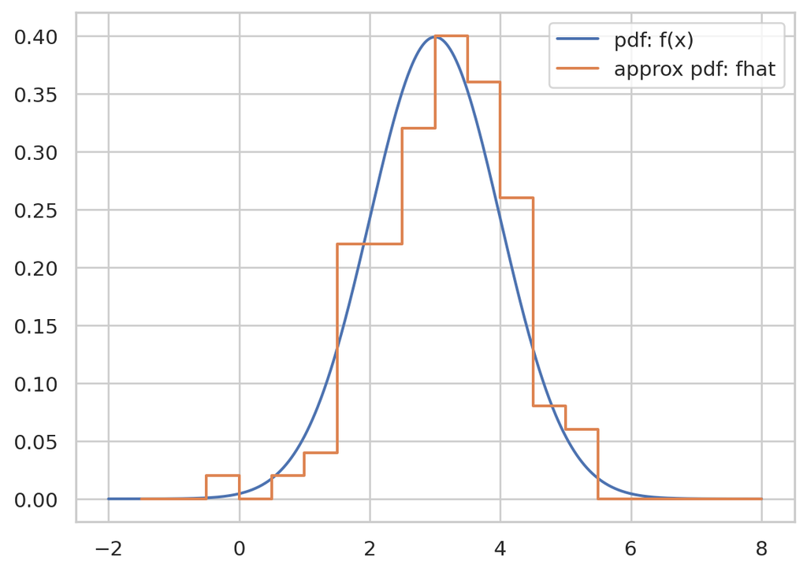

Continuous Approximation

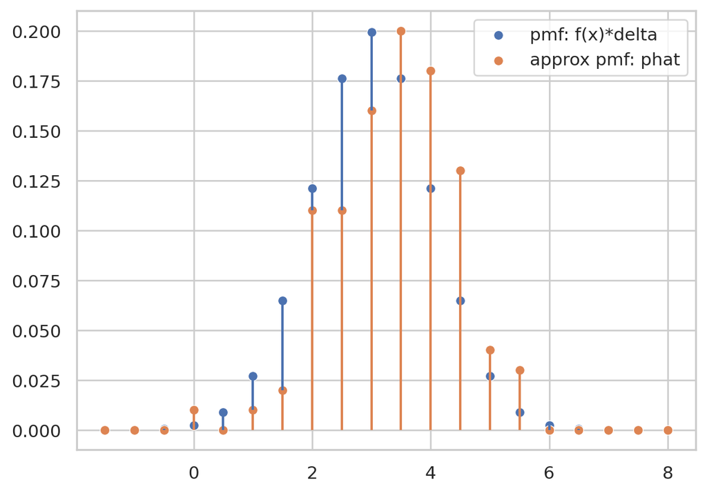

Discrete Approximation

```python
normalize_fhat  = fhat/sum(fhat)          # heights1: just normalizing fhat (constant bin width)
fhat_delta      = fhat*np.diff(bin_edges) # heights2: approximating integral with constant height per bin
bin_probability = counts/num_data         # heights3: probability of being in bin

assert(all(np.isclose(normalize_fhat, fhat_delta)))  # heights1 is equal to heights2
assert(all(np.isclose(fhat_delta, bin_probability))) # heights2 is equal to heights3

midpoints = bin_edges[:-1] + np.diff(bin_edges)
# Seaborn does not natively support step plots or stem plots, but we can use lineplot and scatter for approximation

# fig, ax = plt.subplots(1, 2, figsize=(20, 5))

x_grid = np.linspace(-2, 8, num=1000)

# Continuous approximation: true pdf and histogram density
sns.lineplot(x=x_grid, y=X.pdf(x_grid), label='pdf: f(x)')
sns.lineplot(x=midpoints, y=fhat, label='approx pdf: fhat', drawstyle='steps-pre')
plt.show()

# Discrete approximation: true probabilities and bin probabilities
ax1 =sns.scatterplot(x=midpoints, y=X.pdf(midpoints)*np.diff(bin_edges), marker='o', label='pmf: f(x)*delta')
ax2 = sns.scatterplot(x=midpoints, y=bin_probability, marker='o', label='approx pmf: phat')
ax1.vlines(midpoints, 0, X.pdf(midpoints)*np.diff(bin_edges), color='C0')
ax2.vlines(midpoints, 0, bin_probability, color='C1')
plt.show()
```

## CDF of a continuous distribution

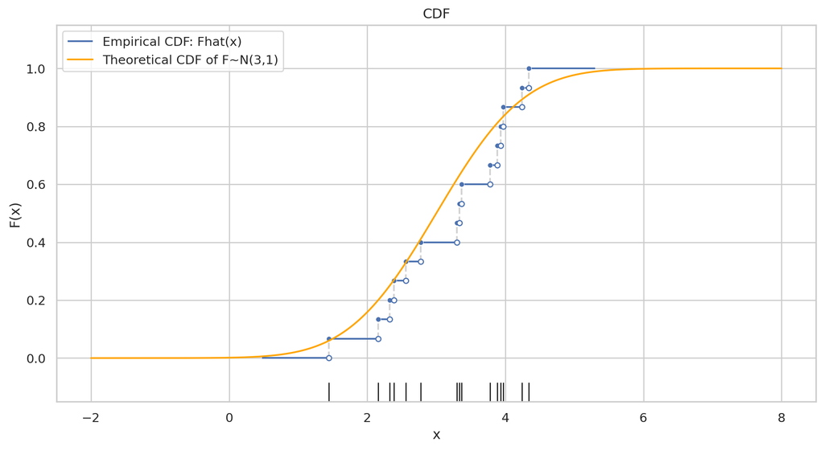

```python
import numpy as np
import matplotlib.pyplot as plt
import seaborn as sns

def ecdf (data):

  v, c = np.unique(data, return_counts=True)
  Fhat = np.cumsum(c/sum(c))

  return v, Fhat

def plot_ecdf(data, dash_color='lightgray', ax=None, labels=None, Fhat=None):
  """
  Plot empirical cumulative distribution function (ECDF) with extended range.

  Parameters:
  -----------
  data : array-like
      Input data for ECDF calculation

  Returns:
  --------
  fig, ax : matplotlib figure and axis objects
  """

  if ax is None:
    fig, ax = plt.subplots()

  if Fhat is None:
    v, Fhat = ecdf(data)
  else:
    v = data
  # v, Fhat = ecdf(data)

  extension = (data.max() - data.min())/3
  marker_size = np.diff(Fhat).mean()*300

  if ax.lines or ax.collections:

    # figure out data range from axis limits and margins
    xmin, xmax = ax.get_xlim()
    lmar, rmar = ax.margins()
    data_rng = (xmax - xmin)/(1 + lmar + rmar)
    dmin = xmin + lmar*data_rng
    dmax = xmax - rmar*data_rng

    v = np.insert(v, 0, dmin)
    v = np.append(v, dmax)

  else:

    v = np.insert(v, 0, v[0]-extension)
    v = np.append(v, v[-1]+extension)

  Fhat = np.insert(Fhat, 0, 0)

  sns.scatterplot(x=v[1:-1], y=Fhat[1:], s=marker_size, ax=ax, zorder=2, legend=False)
  c = ax.collections[-1].get_facecolors()
  sns.scatterplot(x=v[1:-1], y=Fhat[:-1], s=marker_size, color="white", edgecolor=c, linewidth=1, ax=ax, zorder=2, legend=False)

  # Draw flat lines and dashed vertical lines
  ax.hlines(y=Fhat, xmin=v[:-1], xmax=v[1:], color=c, zorder=1, label=labels)
  ax.vlines(x=v[1:-1], ymin=Fhat[:-1], ymax=Fhat[1:], color=dash_color, linestyle='dashed', zorder=1)

  return ax

np.random.seed(134)

x_data = X.rvs(15) # simulate data

fig, ax = plt.subplots(1, 1, figsize=(12, 6))

# Empirical CDF as a step plot
plot_ecdf(x_data, ax=ax, labels='Empirical CDF: Fhat(x)')

# Theoretical CDF as a lineplot
ax = sns.lineplot(x=x_grid, y=X.cdf(x_grid), ax=ax, label='Theoretical CDF of F~N(3,1)', color='orange')

# ax.step(x_os, Fhat, where='post', color='b', label='Empirical CDF: Fhat(x)')

# Observations as rug plot
sns.rugplot(x=x_data, ax=ax, height=0.05, color='k')

ax.set_title('CDF')
ax.set_xlabel('x')
ax.set_ylabel('F(x)')
ax.legend()
plt.show()
```

## Cumulative Distribution Function (CDF)

- Histograms depdend on bin width and bin edges we define.
- Cumulative Distribution Function (CDF) does not depend on binning.
- For discrete distributions (pmf):
  $$F(x) = P(X \leq x) = \sum_{x_i \leq x} p(x_i)$$
- For continuous distributions (pdf):
  $$F(x) = P(X \leq x) = \int_{-\infty}^x f(z)\, dz$$
- CDF is a non-decreasing function $[0, 1]$ as $x$ goes from $-\infty$ to $\infty$ and related to pdf/pmf as:
  - Discrete: $p(x) = F(x) - F(x^-)$
  - Continuous: $f(x) = \frac{d}{dx}F(x)$

## Histogram with $n$ nonzero bins

**NoteEmpirical Distribution Function, $\hat{F}$**

Having observed a random sample of size $n$ from a probability distribution $F$,

$$F \rightarrow\left(x_1, x_2, \cdots, x_n\right)$$

the empirical distribution function $\hat{F}$ is defined to be the discrete distribution that puts probability $1 / n$ on each value $x_i, i=$ $1,2, \cdots, n$. In other words, $\hat{F}$ assigns to a set $A$ in the sample space of $x$ its empirical probability

$$\widehat{\operatorname{Prob}}\{A\}=\#\left\{x_i \in A\right\} / n$$

the proportion of the observed sample $\mathbf{x}=\left(x_1, x_2, \cdots, x_n\right)$ occurring in $A$. We will also write $\operatorname{Prob}_{\hat{F}}\{A\}$ to indicate $\widehat{\operatorname{Prob}}\{A\}$. The hat symbol ” $\wedge$ ” always indicates quantities calculated from the observed data.

. . .

Empirical distribution $\hat{F}$ is a cumulative distribution function (CDF) with probability mass function (pmf) $\hat{p}(x_i) = 1/n$ for $i=1,2,\dots,n$, for both discrete and continuous $F$.

## Empirical CDF of a discrete distribution

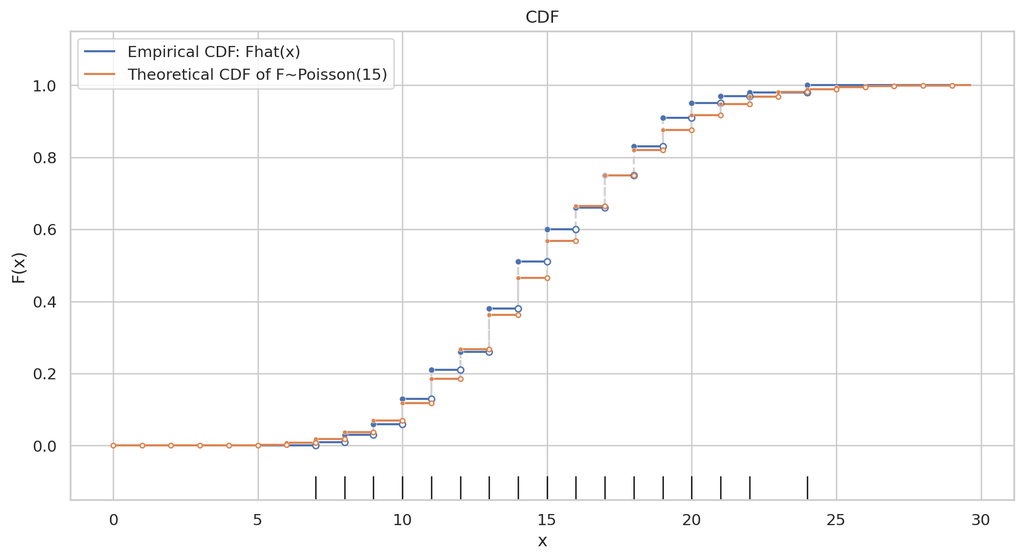

```python
np.random.seed(134)

from scipy.stats import poisson

# Define a Poisson distribution with lambda=5
lambda_param = 15
X_poisson = poisson(mu=lambda_param)

# Generate sample data from Poisson distribution
num_data = 100
x_data = X_poisson.rvs(num_data)

# Create grid for theoretical CDF
x_grid = np.arange(0, 30)

# Calculate empirical CDF
x_os, Fhat = ecdf(x_data)

fig, ax = plt.subplots(1, 1, figsize=(12, 6))

# Theoretical CDF as a lineplot
# sns.scatterplot(x=x_grid, y=X_poisson.cdf(x_grid), ax=ax, color='r', label='Theoretical CDF of F~Poisson(15)')
# sns.lineplot(x=x_grid, y=X_poisson.cdf(x_grid), ax=ax, color='r', label='Theoretical CDF of F~Poisson(15)')

# Empirical CDF as a step plot
plot_ecdf(x_data, ax=ax, labels='Empirical CDF: Fhat(x)')

plot_ecdf(x_grid, Fhat=X_poisson.cdf(x_grid), ax=ax, labels='Theoretical CDF of F~Poisson(15)', dash_color='lightgray')

# ax.step(x_os, Fhat, where='post', color='b', label='Empirical CDF: Fhat(x)')

# Observations as rug plot
sns.rugplot(x=x_os, ax=ax, height=0.05, color='k')

ax.set_title('CDF')
ax.set_xlabel('x')
ax.set_ylabel('F(x)')
ax.legend()
plt.show()
```

## Empirical Cumulative Distribution Function

- Recall our data $x_i$, where $i=1,2,\dots,n$ and order statistic, $x_{(i)}$.
- We can approximate $F(x)$ with $\hat F(x)$ at discrete points $x_{(i)}$ as:
  $$\begin{aligned}
  F(x) = &P(X\leq x) = \int_{-\infty}^x f(z)\, dz\\
  &\hat P(X< x_{(1)}) = 0\\
  \hat F(x_{(1)}) = &\hat P(X\leq x_{(1)}) = 1/n\\
  \hat F(x_{(2)}) = &\hat P(X\leq x_{(2)}) = 2/n\\
  &\vdots \\
  \hat F(x_{(n)}) = &\hat P(X\leq x_{(n)}) = n/n = 1\\
  \end{aligned}$$

## Parameter vs. Statistic

- A *parameter* is a numerical characteristic of the population or true distribution, e.g., mean, variance, quantiles, etc.
- A *statistic* is a numerical characteristic of a sample, e.g., sample mean, sample variance, sample quantiles, etc.
- A statistic is used to estimate a parameter.

## Example: Sample Mean

For a discrete approximation $\hat{F}(x) = \hat p(x_i) = 1/n$, of a *continuous distribution* $F$,

- $\mu_F = E_F(X)$ is a parameter.
- $\hat{\mu}_{\hat{F}} = E_{\hat{F}}(X)$ is called a plug-in estimator

$$\hat{\mu}_{\hat{F}} = \underbrace{E_{\hat{F}}(X) = \sum_{i=1}^n x_i \cdot \hat{p}(x_i)}_\text{Plugin Estimator} = \underbrace{\frac{1}{n} \sum_{i=1}^n x_i = \bar{x}}_\text{Sample Statistic}$$

. . .

Note the $E_{\hat{F}}$ is expectation under discrete distribution with pmf $\hat{p}(x_i) = 1/n$.

## Example: Sample Variance

- $\sigma^2_F = \text{Var}_F(X) = E_F[(X - \mu_F)^2]$ is a parameter.
- $\hat{\sigma}^2_{\hat{F}} = \text{Var}_{\hat{F}}(X) = E_{\hat{F}}[(X - \hat{\mu}_{\hat{F}})^2]$ is called a plug-in estimator

$$\begin{aligned}
\hat{\sigma}_{\hat{F}}^2 &= \overbrace{E_{\hat{F}}[(X - \hat{\mu}_{\hat{F}})^2] = \sum_{i=1}^n (x_i - \hat{\mu}_{\hat{F}})^2 \cdot \hat{p}(x_i)}^{\text{Plugin Estimator}} \\
&= \underbrace{\frac{1}{n} \sum_{i=1}^n (x_i - \bar{x})^2 = s^2}_{\text{Sample Statistic}}
\end{aligned}$$

. . .

Note that $\hat{\sigma}^2_{\hat{F}}$ is using a plugin estimator for mean, $\hat{\mu}_{\hat{F}}$.

## Uncertainty Quantification

- If we know the population distribution $F$, repeatedly sample from it and compute the statistic of interest.
- This would give us the sampling distribution of the statistic.
- However, typically $F$ is unknown
- Can we quantify uncertainty of a statistic from one observed dataset?
- We can use the empirical distribution $\hat{F}$ in place of $F$.
- This is the idea of bootstrap.

## Repeated Sampling from Population

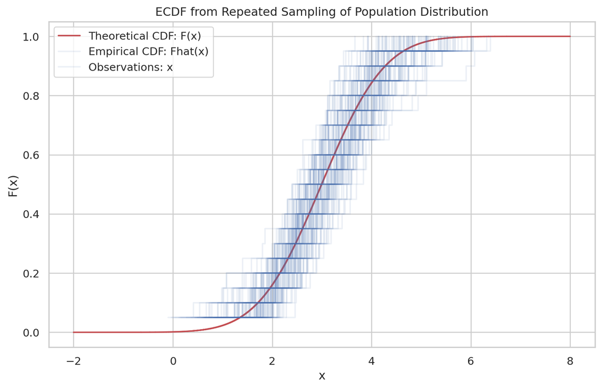

```python
def resample_ecdf(data):
    n = len(data)
    resampled_data = np.random.choice(data, len(data))
    return ecdf(resampled_data)

many_independent_ecdfs = [ecdf(X.rvs(20)) for one in range(0, 100)]

fig, ax = plt.subplots(1, 1, figsize=(10, 6))

x_grid = np.linspace(-2, 8, num=1000)
ax.step(x_grid, X.cdf(x_grid), '-r')
for one_ecdf in many_independent_ecdfs:
    ax.step(*one_ecdf, '-b', alpha=0.1, where='post')

ax.set_title('ECDF from Repeated Sampling of Population Distribution')
ax.set_xlabel('x')
ax.set_ylabel('F(x)')
ax.legend(['Theoretical CDF: F(x)', 'Empirical CDF: Fhat(x)', 'Observations: x'])
plt.show()
```

## Real World vs. Bootstrap World

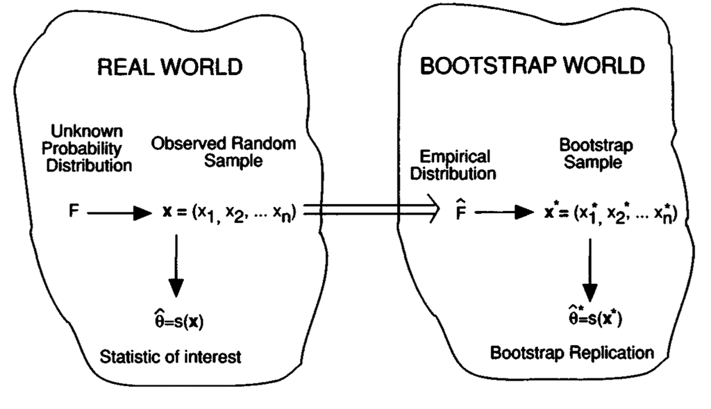

Image source: Introduction to Bootstrap, Efron and Tibshirani (1994)

## Inverse Transform Sampling

- Given $U{\sim}\text{Uniform}(0,1)$ and a CDF $F$ of some distribution,
- What transformation $g(U) = X$ yields $X\sim F$?
- Assume $F$ is invertible and non-decreasing,  
  $X = g(U) = F^{-1}(U)$ gives $X\sim F$.

. . .

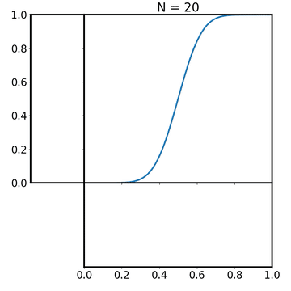

Image source: Wikipedia

## Inverse Transform Sampling: Empirical Distribution

- Similarly, $X = \hat F^{-1}(U)$ yields $X\sim \hat{F}$ with $\hat{p}(x_i) = 1/n$.
- Equivalently, sampling observations from $x_1, x_2, \dots, x_n$ at random with replacement yields $X\sim \hat F$.

. . .

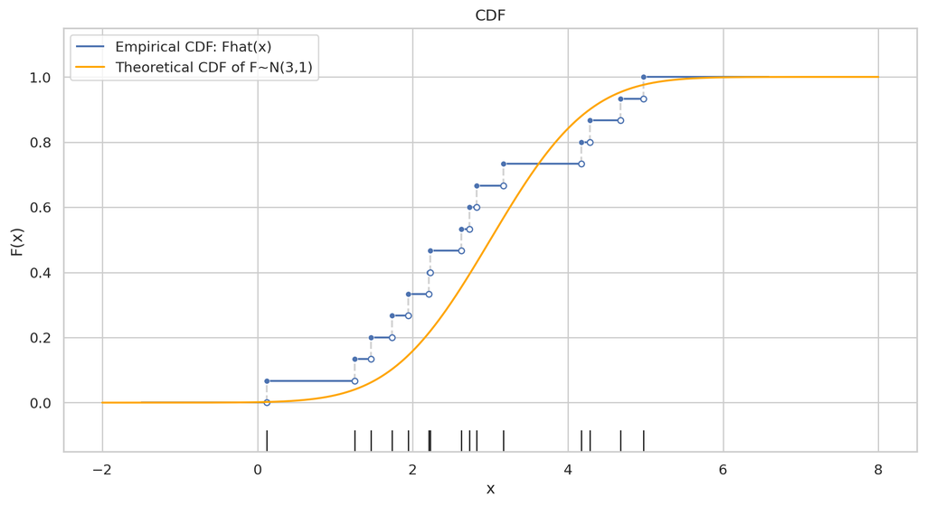

## Bootstrap Algorithm

Given dataset $D$ with $n$ observations,

### Inverse Transform Sampling

1. For $i=1,2,\dots,n$
   1. Sample $u_i$ from Uniform(0,1)
   2. $y_i^* = \hat F^{-1}(u_i)$,
2. Return $D^* = y^*_1, y^*_2, \dots y^*_n$

### Sampling with Replacement

1. For $i=1,2,\dots,n$
   1. Sample a random integer $i\in [1, n]$
   2. $y^*_i = y_{(i)}$,
2. Return $D^* = y^*_1, y^*_2, \dots y^*_n$

. . .

Each $D^*$ is called a bootstrap sample.

## Resampling from Population Distribution

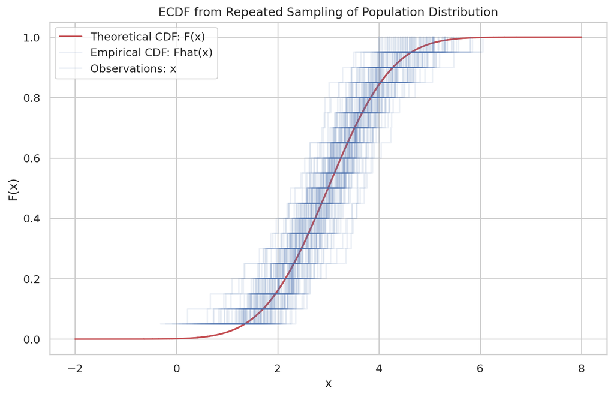

```python
def resample_ecdf(data):
    n = len(data)
    resampled_data = np.random.choice(data, len(data))
    return ecdf(resampled_data)

many_independent_ecdfs = [ecdf(X.rvs(20)) for one in range(0, 100)]

fig, ax = plt.subplots(1, 1, figsize=(10, 6))

ax.step(x_grid, X.cdf(x_grid), '-r')
for one_ecdf in many_independent_ecdfs:
    ax.step(*one_ecdf, '-b', alpha=0.1, where='post')

ax.set_title('ECDF from Repeated Sampling of Population Distribution')
ax.set_xlabel('x')
ax.set_ylabel('F(x)')
ax.legend(['Theoretical CDF: F(x)', 'Empirical CDF: Fhat(x)', 'Observations: x'])
plt.show()
```

## Resampling from Empirical (Data) Distribution

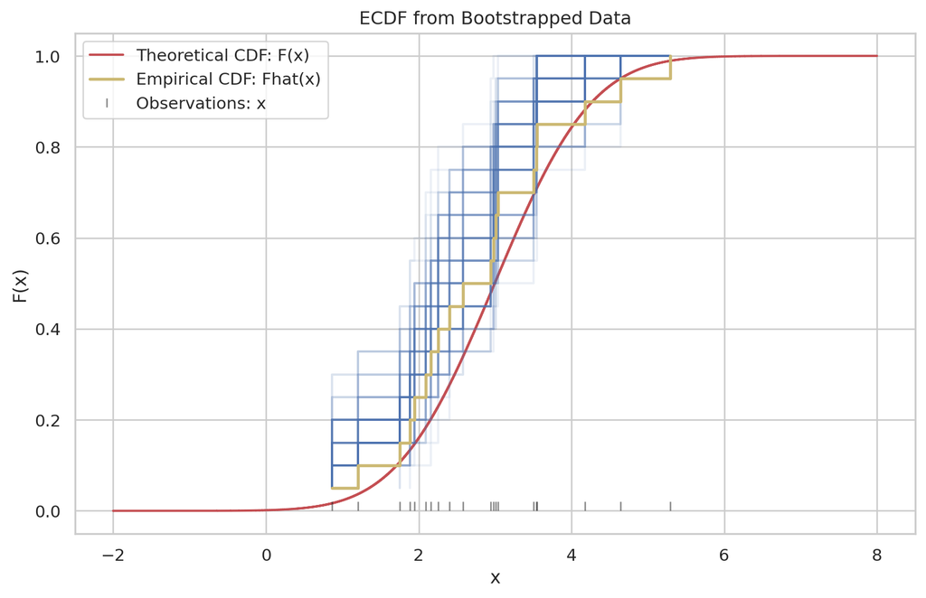

```python
np.random.seed(2)

x_data = X.rvs(20) # simulate data
many_resampled_ecdfs = [resample_ecdf(x_data) for one in range(0, 100)]

x_os, Fhat = ecdf(x_data)

fig, ax = plt.subplots(1, 1, figsize=(10, 6))

ax.step(x_grid, X.cdf(x_grid), '-r')
ax.step(x_os, Fhat, '-y', zorder=10, linewidth=2, where='post')
ax.plot(x_os, [0.01]*len(x_os), '|', color='k', alpha=0.5)

for one_ecdf in many_resampled_ecdfs:
  ax.step(*one_ecdf, '-b', alpha=0.1)

ax.set_title('ECDF from Bootstrapped Data')
ax.set_xlabel('x')
ax.set_ylabel('F(x)')
ax.legend(['Theoretical CDF: F(x)', 'Empirical CDF: Fhat(x)', 'Observations: x'])
plt.show()
```

## Repeated Estimation from Resampled Data

- Imagine if you had non-representative data
- You can use bootstrap to quantify uncertainty of your estimate
- Bootstrap doesn’t work well with small sample sizes
- It may not capture the true variability of the population

. . .

#### Resampled Data in Practice: AI model training

- Resampling is widely used in AI model training
- It helps in creating diverse training datasets (image augmentations, text paraphrasing, etc.)
- Can improve model robustness and generalization

## AI Model Collapse

[figure not shown]

Source: Nature

**NoteModel Collapse in Generative AI Models (Shumailov et al., 2024)**

Model collapse is a degenerative process affecting generations of learned generative models, in which the data they generate end up polluting the training set of the next generation. Being trained on polluted data, they then mis-perceive reality.

We separate two special cases: early model collapse and late model collapse. In early model collapse, the model begins losing information about the tails of the distribution; in late model collapse, the model converges to a distribution that carries little resemblance to the original one, often with substantially reduced variance.

. . .

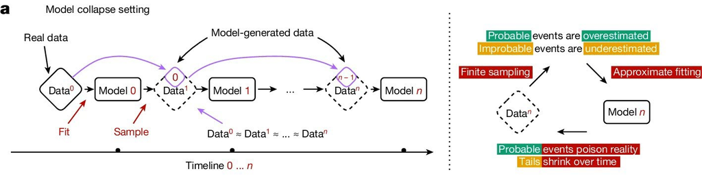

Source: Nature

## References

Efron, Bradley, and R. J. Tibshirani. 1994. *An Introduction to the Bootstrap*. 0th ed. Chapman and Hall/CRC. https://doi.org/10.1201/9780429246593.

## Footnotes

[^1]: Here, $X_i$ are not random variables